# Neural network classifier with Keras

Created on JupyterLab

## Introduction

Here, the popular MNIST dataset will be analysed.

The **MNIST database**, short for Modified National Institute of Standards and Technology database, is a large database of handwritten digits that is commonly used for training various image processing systems. The database is also widely used for training and testing in the field of machine learning.

The MNIST database contains 60,000 training images and 10,000 testing images of digits written by high school students and employees of the United States Census Bureau.

1. Import Keras and Packages
2. Build a Neural Network
3. Train and Test the Network

## Import Keras and Packages

Let's start by importing Keras and some of its modules.

```python
# Libraries
#!pip install numpy==1.21.4
#!pip install pandas==1.3.4
#!pip install keras==2.1.6
#!pip install matplotlib==3.5.0
```

```python
import keras

from keras.models import Sequential
from keras.layers import Dense
from keras.utils import to_categorical
```

Since we are dealing we images, let's also import the Matplotlib scripting layer in order to view the images.

```python
import matplotlib.pyplot as plt
```

The Keras library conveniently includes the MNIST dataset as part of its API. You can check other datasets within the Keras library here.

So, let's load the MNIST dataset from the Keras library. The dataset is readily divided into a training set and a test set.

```python
# import the data
from keras.datasets import mnist

# read the data
(X_train, y_train), (X_test, y_test) = mnist.load_data()
```

```
Downloading data from https://s3.amazonaws.com/img-datasets/mnist.npz
```

Let's confirm the number of images in each set. According to the dataset's documentation, we should have 60000 images in X_train and 10000 images in the X_test.

```python
X_train.shape
```

```
(60000, 28, 28)
```

The first number in the output tuple is the number of images, and the other two numbers are the size of the images in datset. So, each image is 28 pixels by 28 pixels.

Let's visualize the first image in the training set using Matplotlib's scripting layer.

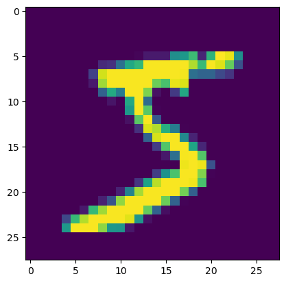

```python
plt.imshow(X_train[0])
```

With conventional neural networks, we cannot feed in the image as input as is. So **we need to flatten the images into one-dimensional vectors, each of size 1 x (28 x 28) = 1 x 784.**

```python
# flatten images into one-dimensional vector

num_pixels = X_train.shape[1] * X_train.shape[2] # find size of one-dimensional vector

X_train = X_train.reshape(X_train.shape[0], num_pixels).astype('float32') # flatten training images
X_test = X_test.reshape(X_test.shape[0], num_pixels).astype('float32') # flatten test images
```

Since pixel values can range from 0 to 255, let's normalize the vectors to be between 0 and 1.

```python
# normalize inputs from 0-255 to 0-1
X_train = X_train / 255
X_test = X_test / 255
```

Finally, before we start building our model, remember that **for classification we need to divide our target variable into categories**. We use the *to_categorical* function from the Keras Utilities package.

```python
# one hot encode outputs
y_train = to_categorical(y_train)
y_test = to_categorical(y_test)

num_classes = y_test.shape[1]
print(num_classes)
```

```
10
```

## Build a Neural Network

```python
# define classification model
def classification_model():
    # create model
    model = Sequential()
    model.add(Dense(num_pixels, activation='relu', input_shape=(num_pixels,)))
    model.add(Dense(100, activation='relu'))
    model.add(Dense(num_classes, activation='softmax'))


    # compile model
    model.compile(optimizer='adam', loss='categorical_crossentropy', metrics=['accuracy'])
    return model
```

The above function create a model that has 2 hidden layers. The second layes is of 100 hidden units.

The activation function is Relu and Softmax for the output layer, so that the sum of the predicted values from all the neurons in the output layer sum nicely to 1. The loss function is the categorical crossentropy. The optimizer is Adam.

The metric to be evaluated by the model during training and testing is the accuracy.

## Train and Test the Network

```python
# build the model
model = classification_model()
```

[output not shown]

```python
# fit the model
model.fit(X_train, y_train, validation_data=(X_test, y_test), epochs=10, verbose=2)

# evaluate the model
scores = model.evaluate(X_test, y_test, verbose=0)
```

[output not shown]

[output not shown]

```
 - 82s - loss: 0.1885 - acc: 0.9423 - val_loss: 0.1013 - val_acc: 0.9670
 - 66s - loss: 0.0805 - acc: 0.9749 - val_loss: 0.0835 - val_acc: 0.9735
 - 62s - loss: 0.0563 - acc: 0.9822 - val_loss: 0.0701 - val_acc: 0.9782
 - 66s - loss: 0.0401 - acc: 0.9867 - val_loss: 0.0712 - val_acc: 0.9801
 - 62s - loss: 0.0299 - acc: 0.9904 - val_loss: 0.0652 - val_acc: 0.9828
 - 65s - loss: 0.0273 - acc: 0.9909 - val_loss: 0.0732 - val_acc: 0.9809
 - 66s - loss: 0.0220 - acc: 0.9926 - val_loss: 0.0669 - val_acc: 0.9817
 - 70s - loss: 0.0185 - acc: 0.9943 - val_loss: 0.0848 - val_acc: 0.9816
 - 64s - loss: 0.0193 - acc: 0.9938 - val_loss: 0.1065 - val_acc: 0.9766
 - 69s - loss: 0.0156 - acc: 0.9951 - val_loss: 0.0810 - val_acc: 0.9822
```

Let's print the accuracy and the corresponding error.

```python
print('Accuracy: {}% \n Error: {}'.format(scores[1], 1 - scores[1]))
```

```
Accuracy: 0.9822%
 Error: 0.017800000000000038
```

Sometimes, you cannot afford to retrain your model everytime you want to use it, especially if you are limited on computational resources and training your model can take a long time. Therefore, with the Keras library, you can save your model after training. To do that, we use the save method.

```python
model.save('classification_model.h5')
```

Since our model contains multidimensional arrays of data, then models are usually saved as .h5 files.

When you are ready to use your model again, you use the load_model function from **keras.models**.

```python
from keras.models import load_model
```

```python
pretrained_model = load_model('classification_model.h5')
```

# Authors' rights

Machine Learning with Python course by IBM on Coursera: https://www.coursera.org/learn/machine-learning-with-python/

Completed and modified by Mathilde Marie Duville as part of the IBM Artificial Intelligence Engineering Professional Certificate and corresponding IBM badges. Please, follow the subsequent links to confirm the accreditation:

https://www.coursera.org/account/accomplishments/professional-cert/KSLW773DAATP?utm_source=link&utm_medium=certificate&utm_content=cert_image&utm_campaign=sharing_cta&utm_product=prof

https://www.credly.com/users/mathilde-marie-duville/badges

Author: Alex Aklson.

Change Log

| Date (YYYY-MM-DD) | Version | Changed By | Change Description |
| --- | --- | --- | --- |
| 2020-09-21 | 2.0 | Srishti | Migrated Lab to Markdown and added to course repo in GitLab |

© IBM Corporation 2020. All rights reserved.

This notebook is part of a course on **Coursera** called *Introduction to Deep Learning & Neural Networks with Keras*. If you accessed this notebook outside the course, you can take this course online by clicking [here](https://cocl.us/DL0101EN_Coursera_Week3_LAB2).

Copyright © 2019 IBM Developer Skills Network. This notebook and its source code are released under the terms of the MIT License.